# sklearn.ensemble.IsolationForest

**class*sklearn.ensemble.IsolationForest(*, *n_estimators=100*, *max_samples='auto'*, *contamination='auto'*, *max_features=1.0*, *bootstrap=False*, *n_jobs=None*, *random_state=None*, *verbose=0*, *warm_start=False*)[[source]](https://github.com/scikit-learn/scikit-learn/blob/f3f51f9b6/sklearn/ensemble/_iforest.py#L25)**

Isolation Forest Algorithm.

Return the anomaly score of each sample using the IsolationForest algorithm

The IsolationForest ‘isolates’ observations by randomly selecting a feature and then randomly selecting a split value between the maximum and minimum values of the selected feature.

Since recursive partitioning can be represented by a tree structure, the number of splittings required to isolate a sample is equivalent to the path length from the root node to the terminating node.

This path length, averaged over a forest of such random trees, is a measure of normality and our decision function.

Random partitioning produces noticeably shorter paths for anomalies. Hence, when a forest of random trees collectively produce shorter path lengths for particular samples, they are highly likely to be anomalies.

Read more in the User Guide.

New in version 0.18.

**Parameters:**

**n_estimators**int, default=100**

The number of base estimators in the ensemble.

**max_samples**“auto”, int or float, default=”auto”**

**The number of samples to draw from X to train each base estimator.**

- If int, then draw `max_samples` samples.
- If float, then draw `max_samples * X.shape[0]` samples.
- If “auto”, then `max_samples=min(256, n_samples)`.

If max_samples is larger than the number of samples provided, all samples will be used for all trees (no sampling).

**contamination**‘auto’ or float, default=’auto’**

The amount of contamination of the data set, i.e. the proportion of outliers in the data set. Used when fitting to define the threshold on the scores of the samples.

- If ‘auto’, the threshold is determined as in the original paper.
- If float, the contamination should be in the range (0, 0.5].

Changed in version 0.22: The default value of `contamination` changed from 0.1 to `'auto'`.

**max_features**int or float, default=1.0**

The number of features to draw from X to train each base estimator.

- If int, then draw `max_features` features.
- If float, then draw `max(1, int(max_features * n_features_in_))` features.

**bootstrap**bool, default=False**

If True, individual trees are fit on random subsets of the training data sampled with replacement. If False, sampling without replacement is performed.

**n_jobs**int, default=None**

The number of jobs to run in parallel for both `fit` and `predict`. `None` means 1 unless in a [`joblib.parallel_backend`](https://joblib.readthedocs.io/en/latest/parallel.html#joblib.parallel_backend) context. `-1` means using all processors. See [Glossary](https://scikit-learn.org/1.1/glossary.html#term-n_jobs) for more details.

**random_state**int, RandomState instance or None, default=None**

Controls the pseudo-randomness of the selection of the feature and split values for each branching step and each tree in the forest.

Pass an int for reproducible results across multiple function calls. See [Glossary](https://scikit-learn.org/1.1/glossary.html#term-random_state).

**verbose**int, default=0**

Controls the verbosity of the tree building process.

**warm_start**bool, default=False**

When set to `True`, reuse the solution of the previous call to fit and add more estimators to the ensemble, otherwise, just fit a whole new forest. See [the Glossary](https://scikit-learn.org/1.1/glossary.html#term-warm_start).

New in version 0.21.

**Attributes:**

**base_estimator_**ExtraTreeRegressor instance**

The child estimator template used to create the collection of fitted sub-estimators.

**estimators_**list of ExtraTreeRegressor instances**

The collection of fitted sub-estimators.

**estimators_features_**list of ndarray**

The subset of drawn features for each base estimator.

**`estimators_samples_`list of ndarray**

The subset of drawn samples for each base estimator.

**max_samples_**int**

The actual number of samples.

**offset_**float**

Offset used to define the decision function from the raw scores. We have the relation: `decision_function = score_samples - offset_`. `offset_` is defined as follows. When the contamination parameter is set to “auto”, the offset is equal to -0.5 as the scores of inliers are close to 0 and the scores of outliers are close to -1. When a contamination parameter different than “auto” is provided, the offset is defined in such a way we obtain the expected number of outliers (samples with decision function < 0) in training.

New in version 0.20.

**`n_features_`int**

DEPRECATED: Attribute `n_features_` was deprecated in version 1.0 and will be removed in 1.2.

**n_features_in_**int**

Number of features seen during fit.

New in version 0.24.

**feature_names_in_**ndarray of shape (`n_features_in_`,)**

Names of features seen during fit. Defined only when `X` has feature names that are all strings.

New in version 1.0.

See also

**`sklearn.covariance.EllipticEnvelope`**

An object for detecting outliers in a Gaussian distributed dataset.

**`sklearn.svm.OneClassSVM`**

Unsupervised Outlier Detection. Estimate the support of a high-dimensional distribution. The implementation is based on libsvm.

**`sklearn.neighbors.LocalOutlierFactor`**

Unsupervised Outlier Detection using Local Outlier Factor (LOF).

#### Notes

The implementation is based on an ensemble of ExtraTreeRegressor. The maximum depth of each tree is set to `ceil(log_2(n))` where $n$ is the number of samples used to build the tree (see (Liu et al., 2008) for more details).

#### References

[1]

Liu, Fei Tony, Ting, Kai Ming and Zhou, Zhi-Hua. “Isolation forest.” Data Mining, 2008. ICDM’08. Eighth IEEE International Conference on.

[2]

Liu, Fei Tony, Ting, Kai Ming and Zhou, Zhi-Hua. “Isolation-based anomaly detection.” ACM Transactions on Knowledge Discovery from Data (TKDD) 6.1 (2012): 3.

#### Examples

```
>>> from sklearn.ensemble import IsolationForest
>>> X = [[-1.1], [0.3], [0.5], [100]]
>>> clf = IsolationForest(random_state=0).fit(X)
>>> clf.predict([[0.1], [0], [90]])
array([ 1,  1, -1])
```

#### Methods

| `decision_function`(X) | Average anomaly score of X of the base classifiers. |
| --- | --- |
| `fit`(X[, y, sample_weight]) | Fit estimator. |
| `fit_predict`(X[, y]) | Perform fit on X and returns labels for X. |
| `get_params`([deep]) | Get parameters for this estimator. |
| `predict`(X) | Predict if a particular sample is an outlier or not. |
| `score_samples`(X) | Opposite of the anomaly score defined in the original paper. |
| `set_params`(**params) | Set the parameters of this estimator. |

**decision_function(*X*)[[source]](https://github.com/scikit-learn/scikit-learn/blob/f3f51f9b6/sklearn/ensemble/_iforest.py#L349)**

Average anomaly score of X of the base classifiers.

The anomaly score of an input sample is computed as the mean anomaly score of the trees in the forest.

The measure of normality of an observation given a tree is the depth of the leaf containing this observation, which is equivalent to the number of splittings required to isolate this point. In case of several observations n_left in the leaf, the average path length of a n_left samples isolation tree is added.

**Parameters:**

**X**{array-like, sparse matrix} of shape (n_samples, n_features)**

The input samples. Internally, it will be converted to `dtype=np.float32` and if a sparse matrix is provided to a sparse `csr_matrix`.

**Returns:**

**scores**ndarray of shape (n_samples,)**

The anomaly score of the input samples. The lower, the more abnormal. Negative scores represent outliers, positive scores represent inliers.

**property*estimators_samples_**

The subset of drawn samples for each base estimator.

Returns a dynamically generated list of indices identifying the samples used for fitting each member of the ensemble, i.e., the in-bag samples.

Note: the list is re-created at each call to the property in order to reduce the object memory footprint by not storing the sampling data. Thus fetching the property may be slower than expected.

**fit(*X*, *y=None*, *sample_weight=None*)[[source]](https://github.com/scikit-learn/scikit-learn/blob/f3f51f9b6/sklearn/ensemble/_iforest.py#L235)**

Fit estimator.

**Parameters:**

**X**{array-like, sparse matrix} of shape (n_samples, n_features)**

The input samples. Use `dtype=np.float32` for maximum efficiency. Sparse matrices are also supported, use sparse `csc_matrix` for maximum efficiency.

**y**Ignored**

Not used, present for API consistency by convention.

**sample_weight**array-like of shape (n_samples,), default=None**

Sample weights. If None, then samples are equally weighted.

**Returns:**

**self**object**

Fitted estimator.

**fit_predict(*X*, *y=None*)[[source]](https://github.com/scikit-learn/scikit-learn/blob/f3f51f9b6/sklearn/base.py#L956)**

Perform fit on X and returns labels for X.

Returns -1 for outliers and 1 for inliers.

**Parameters:**

**X**{array-like, sparse matrix} of shape (n_samples, n_features)**

The input samples.

**y**Ignored**

Not used, present for API consistency by convention.

**Returns:**

**y**ndarray of shape (n_samples,)**

1 for inliers, -1 for outliers.

**get_params(*deep=True*)[[source]](https://github.com/scikit-learn/scikit-learn/blob/f3f51f9b6/sklearn/base.py#L194)**

Get parameters for this estimator.

**Parameters:**

**deep**bool, default=True**

If True, will return the parameters for this estimator and contained subobjects that are estimators.

**Returns:**

**params**dict**

Parameter names mapped to their values.

**property*n_features_**

DEPRECATED: Attribute `n_features_` was deprecated in version 1.0 and will be removed in 1.2. Use `n_features_in_` instead.

**predict(*X*)[[source]](https://github.com/scikit-learn/scikit-learn/blob/f3f51f9b6/sklearn/ensemble/_iforest.py#L326)**

Predict if a particular sample is an outlier or not.

**Parameters:**

**X**{array-like, sparse matrix} of shape (n_samples, n_features)**

The input samples. Internally, it will be converted to `dtype=np.float32` and if a sparse matrix is provided to a sparse `csr_matrix`.

**Returns:**

**is_inlier**ndarray of shape (n_samples,)**

For each observation, tells whether or not (+1 or -1) it should be considered as an inlier according to the fitted model.

**score_samples(*X*)[[source]](https://github.com/scikit-learn/scikit-learn/blob/f3f51f9b6/sklearn/ensemble/_iforest.py#L381)**

Opposite of the anomaly score defined in the original paper.

The anomaly score of an input sample is computed as the mean anomaly score of the trees in the forest.

The measure of normality of an observation given a tree is the depth of the leaf containing this observation, which is equivalent to the number of splittings required to isolate this point. In case of several observations n_left in the leaf, the average path length of a n_left samples isolation tree is added.

**Parameters:**

**X**{array-like, sparse matrix} of shape (n_samples, n_features)**

The input samples.

**Returns:**

**scores**ndarray of shape (n_samples,)**

The anomaly score of the input samples. The lower, the more abnormal.

**set_params(**params)[[source]](https://github.com/scikit-learn/scikit-learn/blob/f3f51f9b6/sklearn/base.py#L218)**

Set the parameters of this estimator.

The method works on simple estimators as well as on nested objects (such as `Pipeline`). The latter have parameters of the form `<component>__<parameter>` so that it’s possible to update each component of a nested object.

**Parameters:**

**paramsdict**

Estimator parameters.

**Returns:**

**self**estimator instance**

Estimator instance.

## Examples using `sklearn.ensemble.IsolationForest`

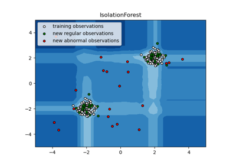

IsolationForest example

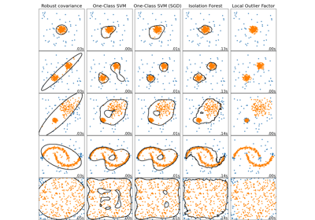

Comparing anomaly detection algorithms for outlier detection on toy datasets

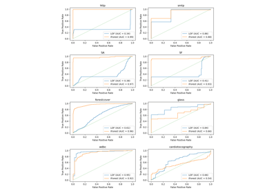

Evaluation of outlier detection estimators

© 2007–2022 The scikit-learn developers  
Licensed under the 3-clause BSD License.  
https://scikit-learn.org/1.1/modules/generated/sklearn.ensemble.IsolationForest.html